# Redundancy Analysis (RDA)

21/jun/2018

This file explains the procedure followed by Ernesto Igartua to perform redundancy analysis on genetic features of the genotypes (probability of belonging to each one of the four germplasm groups), explained by geographic and agro-climatic features of the locations of collection of the genotypes. This uses library **vegan**.

```r
library(vegan)
```

Input of environmental, geographic, genetic data

```r
#Input data, (Q matrix, all geographic and agro-climatic variables for all accessions)
SBCC <- read.table("RDA/RDA_complete.tsv", header = TRUE)

#Probabilities derived from structure, 4 populations or germplasm groups
Cluster <- SBCC[,c("Q1","Q2","Q3","Q4")]

#Dummy variables
Dummies <- SBCC[,6:17]

#All explanatory variables, environmental, geographic, dummies
EnvGeoDum<-SBCC[,6:ncol(SBCC)]

#Just geographic variables
Geo <- SBCC[,c("altitude","utmx","utmy")]

#Just environmental variables, all, non-standardized
Env <- SBCC[,21:ncol(SBCC)]
head(SBCC)
```

```
        structure_cluster    Q1    Q2    Q3    Q4  dummy_01  dummy_02
SBCC001                 1 0.525 0.000 0.449 0.025 1.1319747 0.9428862
SBCC002                 1 0.790 0.001 0.120 0.090 0.9170711 1.1143330
SBCC003                 3 0.075 0.000 0.767 0.158 1.0191159 1.0413141
SBCC004                 1 0.526 0.126 0.149 0.199 1.0668731 1.0424424
SBCC005                 3 0.026 0.001 0.805 0.168 0.9339675 0.9611360
SBCC006                 3 0.040 0.000 0.880 0.080 1.0643861 1.0118885
         dummy_03  dummy_04  dummy_05  dummy_06  dummy_07  dummy_08
SBCC001 0.9517142 0.9672275 0.9582126 0.9624485 1.0230726 0.9751187
SBCC002 1.0708767 1.0701706 1.0953819 1.0844107 0.9313422 0.9940330
SBCC003 1.0017011 1.0582434 1.0069600 0.9374063 1.0025110 1.0312523
SBCC004 0.9286685 1.0242339 0.9740021 0.9672581 0.9665652 0.9782558
SBCC005 0.9243257 1.0511030 1.0400764 0.9597972 0.9874042 0.9924280
SBCC006 1.0906860 0.7611184 1.1753876 0.9487512 0.9578449 0.7389713
         dummy_09  dummy_10  dummy_11  dummy_12 altitude   utmx    utmy
SBCC001 0.9767225 1.0010688 0.9460738 1.0757837      482 502732 4723800
SBCC002 1.0349442 0.9778595 0.9645447 1.0799071      540 527235 4744210
SBCC003 0.9880549 0.9848837 1.0249680 0.9795045      685 487315 4498070
SBCC004 0.9860799 1.0216805 1.0403354 0.9700889      821 355768 4547580
SBCC005 1.0179045 1.0233084 0.9506567 1.0640068      564 253330 4370640
SBCC006 0.9925718 1.1401919 0.9582850 1.0342159       40 796705 4522510
         tamp_aut tamp_spr  tamp_win   tamp_01   tamp_02  tamp_03  tamp_04
SBCC001 10.364702 11.22652  7.522248  7.107619  8.698300 10.69802 11.11819
SBCC002 10.280801 10.93643  7.801900  7.521173  8.912690 10.59006 10.74763
SBCC003 12.587445 13.37007 10.303525 10.091963 11.632977 13.30806 12.97233
SBCC004 12.255573 13.10919  9.308032  8.798272 10.901658 12.82562 12.83884
SBCC005 11.045733 11.91527  8.836782  8.770574  9.651395 11.14923 11.62650
SBCC006  9.800245 11.03953  8.993074  8.765983  9.800018 10.91975 11.02245
         tamp_05  tamp_06   tamp_11  tamp_12 et0_annual     bal_01
SBCC001 11.87548 13.05807  7.966463 6.894517  1010.2940  16.030180
SBCC002 11.51205 12.39278  8.039158 7.183892   946.3984  47.748058
SBCC003 13.78787 15.66418 10.393627 9.311220  1190.0853   6.483904
SBCC004 13.65312 15.80469  9.666140 8.316976  1148.9209   9.759199
SBCC005 13.01388 14.95655  9.010626 8.086374  1259.1362  33.579746
SBCC006 11.15042 11.40402  8.710864 8.401956  1260.8562 -10.490158
            bal_02     bal_03     bal_04    bal_05     bal_06   bal_11
SBCC001  -1.316006 -32.214577 -29.431923 -58.54840  -89.56256 25.93165
SBCC002  25.985321  -3.201065  -2.130508 -37.13115  -75.67059 55.65340
SBCC003  -9.479664 -53.222786 -46.435722 -81.24417 -142.64290 14.04456
SBCC004 -11.491652 -50.191227 -52.717690 -71.78388 -131.76453 12.48698
```

[output cut: 78 more lines]

```
SBCC006 17.10206 8.993849 5.7970200  5.0448809 5.64280748 9.670547
        verna_d_01 verna_d_02 verna_d_03 verna_d_04 verna_01 verna_02
SBCC001   15.42000   28.64593   42.45234   56.53029 44.96055 65.64942
SBCC002   14.98455   28.54227   43.24152   58.23542 43.75400 63.23307
SBCC003   16.96500   32.26210   48.10253   64.19965 40.33420 58.34750
SBCC004   15.62109   29.92539   45.36249   61.82481 41.19423 59.56752
SBCC005   17.82721   32.13572   46.17304   59.72951 42.82933 63.18630
SBCC006   23.13376   40.22333   56.71679   73.33250 34.72694 52.11789
        verna_03  verna_04  verna_05  verna_06 verna_11 verna_12
SBCC001 84.25145 102.06100 115.84116 122.62193 71.38354 22.94700
SBCC002 81.33349  99.96902 115.66930 124.58776 75.20112 22.75618
SBCC003 74.70019  90.34036 102.79706 108.69465 63.80278 20.46584
SBCC004 76.77201  93.97660 108.13731 115.59081 69.87321 21.31396
SBCC005 79.77531  93.03412 102.05942 105.21869 56.54910 20.49502
SBCC006 66.31318  76.29522  81.29912  82.12591 42.19517 15.92693
```

```r
#Input data for a third redundancy analysis. Input of set of variables chosen by cluster analysis, 17 agro-climatic, plus 3 geographic and 12 dummies; they are already standardized

#Input data, (Q matrix, all geographic and agro-climatic variables for all accessions)
SBCCc<- read.table("RDA/RDA3.tsv", header = TRUE)

#All variables, geographical, dummies, environmental, all standardized
Allc<-SBCCc[,c("dummy_01","dummy_02","dummy_03","dummy_04","dummy_05","dummy_06","dummy_07",
             "dummy_08","dummy_09","dummy_10","dummy_11","dummy_12","lon","lat","alt",
             "verna_30d","verna_jan_feb","verna_mar_apr","pfrost_01","pcp_aut","pcp_win",
             "pcp_mar_apr","pcp_may_jun","frost_jan_feb","frost_apr_may","tamp_win",
             "tamp_spr","et0_spr","bal_aut","bal_win","bal_jun","bal_mar_apr_may")]

#Just dummies
Dummyc<-SBCCc[,c("dummy_01","dummy_02","dummy_03","dummy_04","dummy_05","dummy_06","dummy_07",
             "dummy_08","dummy_09","dummy_10","dummy_11","dummy_12")]

#Just geographic
Geoc<-SBCCc[,c("lon","lat","alt")]

#Just environmental (agro-climatic)
Envc<-SBCCc[,c("verna_30d","verna_jan_feb","verna_mar_apr","pfrost_01","pcp_aut","pcp_win",
             "pcp_mar_apr","pcp_may_jun","frost_jan_feb","frost_apr_may","tamp_win",
             "tamp_spr","et0_spr","bal_aut","bal_win","bal_jun","bal_mar_apr_may")]

#Just probabilities derived from structure, 4 populations or germplasm groups
Clusterc <- SBCCc[,c("Q1","Q2","Q3","Q4")]
```

Standardization of variables

```r
#Standardization of variables
scaled.EnvGeoDum<-scale(EnvGeoDum)
scaledEnvGeoDum.df<-as.data.frame(scaled.EnvGeoDum)

scaled.env<-scale(Env)
scaledenv.df <- as.data.frame(scaled.env)

scaled.geo<-scale(Geo)
scaledgeo.df <- as.data.frame(scaled.geo)
```

First redundancy analysis with just environmental (agroclimatic) variables. Then selection of most significant variables is done with step-wise regression, and a second, reduced, redundancy analysis is performed, with just the variables selected in multiple regression with default settings, until the first dummy variable was entered into the model.

```r
#Redundancy analysis, complete data set
SBCC_RDA<-rda(Cluster,scaledenv.df,scale=F)

#Stepwise selection of variables, complete data, environmental, geographic and dummy variables
RDA1<-rda(Cluster~1,scaledEnvGeoDum.df)
RDA2<-rda(Cluster~.,scaledEnvGeoDum.df)
step.forward<-ordistep(RDA1,scope=formula(RDA2), direction="forward",perm.max=200,pstep=999)
```

```
Start: Cluster ~ 1

             Df     AIC       F Pr(>F)
+ pfrost_01   1 -141.52 26.8422  0.005 **
+ verna_11    1 -139.86 24.8929  0.005 **
+ tmin_11     1 -139.64 24.6281  0.005 **
+ tmed_01     1 -139.62 24.6034  0.005 **
+ tmed_aut    1 -139.62 24.6034  0.005 **
+ tmax_01     1 -139.43 24.3899  0.005 **
+ tmax_aut    1 -139.43 24.3899  0.005 **
+ tmed_11     1 -139.43 24.3824  0.005 **
+ tmin_04     1 -139.24 24.1609  0.005 **
+ tmin_win    1 -139.24 24.1609  0.005 **
+ tmin_05     1 -139.03 23.9229  0.005 **
+ tmax_12     1 -139.02 23.9061  0.005 **
+ tmin_03     1 -139.02 23.9061  0.005 **
+ tmed_12     1 -138.98 23.8604  0.005 **
+ tmin_02     1 -138.81 23.6691  0.005 **
+ tmin_spr    1 -138.81 23.6691  0.005 **
+ verna_06    1 -138.49 23.2954  0.005 **
+ tmed_02     1 -138.18 22.9363  0.005 **
+ tmed_spr    1 -138.18 22.9363  0.005 **
+ tmax_11     1 -138.17 22.9215  0.005 **
+ tmin_01     1 -138.14 22.8857  0.005 **
+ tmin_aut    1 -138.14 22.8857  0.005 **
+ tmin_12     1 -137.81 22.5080  0.005 **
+ frost_01    1 -137.49 22.1402  0.005 **
+ verna_05    1 -136.69 21.2237  0.005 **
+ frost_win   1 -136.64 21.1682  0.005 **
+ tmed_03     1 -136.43 20.9243  0.005 **
+ tmed_04     1 -136.28 20.7551  0.005 **
+ tmed_win    1 -136.28 20.7551  0.005 **
+ tmin_06     1 -136.00 20.4371  0.005 **
+ tmax_02     1 -135.97 20.4019  0.005 **
+ tmax_spr    1 -135.97 20.4019  0.005 **
+ frost_12    1 -135.85 20.2602  0.005 **
+ frost_02    1 -135.83 20.2375  0.005 **
+ frost_11    1 -135.17 19.4953  0.005 **
+ tmed_05     1 -134.87 19.1504  0.005 **
+ verna_12    1 -134.85 19.1322  0.005 **
```

[output cut: 791 more lines]

```
+ et0_01      1 -154.05 0.1640  0.915
+ tamp_win    1 -154.07 0.1788  0.920
+ tamp_11     1 -154.06 0.1686  0.925
+ tamp_04     1 -154.02 0.1330  0.925
+ tamp_06     1 -154.05 0.1593  0.930
+ et0_03      1 -154.02 0.1285  0.930
+ tamp_02     1 -154.00 0.1163  0.930
+ tmin_spr    1 -154.00 0.1126  0.945
+ tmin_02     1 -154.00 0.1126  0.950
+ tamp_spr    1 -154.00 0.1085  0.960
+ dummy_05    1 -153.92 0.0362  0.975
+ tamp_aut    1 -153.96 0.0771  0.980
+ tamp_03     1 -153.91 0.0271  0.990
---
Signif. codes:  0 '***' 0.001 '**' 0.01 '*' 0.05 '.' 0.1 ' ' 1
```

```r
#Redundancy analysis, complete data reduced to env variables selected by forward selection, until first dummy variable entered in the model
SBCC_RDA_red<-rda(Cluster~pfrost_01+bal_06, data=scaledenv.df)
```

Information on outcome of RDA. Variance inflation ratio informs on multicolinearity (values above 10 are too high). R-squared adjusted for the number of parameters indicates proportion of variation explained

```r
#variance inflation ratio, above 10 indicates multicolinearity
vif.cca(SBCC_RDA)
```

```
    tamp_aut     tamp_spr     tamp_win      tamp_01      tamp_02
4.295162e+02 3.540986e+04 9.302750e+03 8.268138e+03 2.999612e+04
     tamp_03      tamp_04      tamp_05      tamp_06      tamp_11
2.295358e+05 1.211579e+05 8.338348e+04 1.130374e+04 5.594866e+03
     tamp_12   et0_annual       bal_01       bal_02       bal_03
2.970511e+03 1.277254e+04 7.150251e+02 4.111410e+02 8.940493e+12
      bal_04       bal_05       bal_06       bal_11       bal_12
1.615430e+13 5.215773e+14 1.985650e+14 3.575522e+02 1.594152e+03
   bal_anual      bal_aut      bal_spr      bal_win    frost_aut
6.925306e+03 5.317252e+03 1.243565e+14           NA 6.138931e+03
   frost_spr    frost_win     frost_01     frost_02     frost_03
3.807555e+05 6.002322e+05 8.225854e+04 6.746602e+04 1.383191e+05
    frost_04     frost_05     frost_06     frost_11     frost_12
3.887011e+04 3.963422e+03 5.927410e+01 5.502373e+03 5.826062e+04
      et0_01       et0_11       et0_12       et0_02       et0_03
1.312442e+13 2.479961e+03 1.380325e+13 1.377879e+13 2.262344e+03
      et0_04       et0_05       et0_06       pcp_01       pcp_02
2.463415e+03 1.481729e+14 7.257382e+13           NA           NA
      pcp_03       pcp_04       pcp_05       pcp_06       pcp_11
          NA           NA 1.500718e+14 4.477745e+13           NA
      pcp_12      pcp_aut      pcp_spr      pcp_win    pfrost_01
          NA 3.930839e+03 5.580345e+03 3.565956e+03 3.426145e+02
     et0_aut      et0_spr      et0_win      tmax_01      tmax_02
3.435502e+03           NA 1.149129e+14 1.478811e+05 2.707371e+05
     tmax_03      tmax_04      tmax_05      tmax_06      tmax_11
2.347263e+06 1.510571e+06 6.127409e+05 9.157733e+04 1.453267e+05
     tmax_12     tmax_aut     tmax_spr     tmax_win      tmed_01
8.881765e+04           NA           NA           NA 3.277640e+05
     tmed_02      tmed_03      tmed_04      tmed_05      tmed_06
4.902122e+05 6.837286e+06 1.649220e+06 6.168732e+05 2.423067e+05
     tmed_11      tmed_12     tmed_aut     tmed_spr     tmed_win
3.671119e+05 3.157238e+05           NA           NA           NA
     tmin_01      tmin_02      tmin_03      tmin_04      tmin_05
1.057001e+05 3.031936e+05 2.969526e+06 4.684489e+05 5.013898e+05
     tmin_06      tmin_11      tmin_12     tmin_aut     tmin_spr
9.585096e+04 1.551695e+05 1.150441e+05           NA           NA
    tmin_win   verna_d_01   verna_d_02   verna_d_03   verna_d_04
          NA 1.047005e+03 1.039705e+03 1.265439e+03 6.242494e+02
    verna_01     verna_02     verna_03     verna_04     verna_05
2.278741e+04 7.347226e+04 1.243496e+05 2.592596e+05 3.564866e+05
    verna_06     verna_11     verna_12
1.865621e+05 1.192771e+04 4.405101e+03
```

```r
vif.cca(SBCC_RDA_red)
```

```
pfrost_01    bal_06
 1.972673  1.972673
```

```r
#R-squared, raw and adjusted, explained by rda
RsquareAdj(SBCC_RDA_red)
```

```
$r.squared
[1] 0.2348693

$adj.r.squared
[1] 0.2231879
```

```r
RsquareAdj(SBCC_RDA)
```

```
$r.squared
[1] 0.7827899

$adj.r.squared
[1] 0.3853415
```

Plots of both redundancy analyses, scaling=0 chosen, as it results in good visualization of the plot; see help of the package for other scaling options

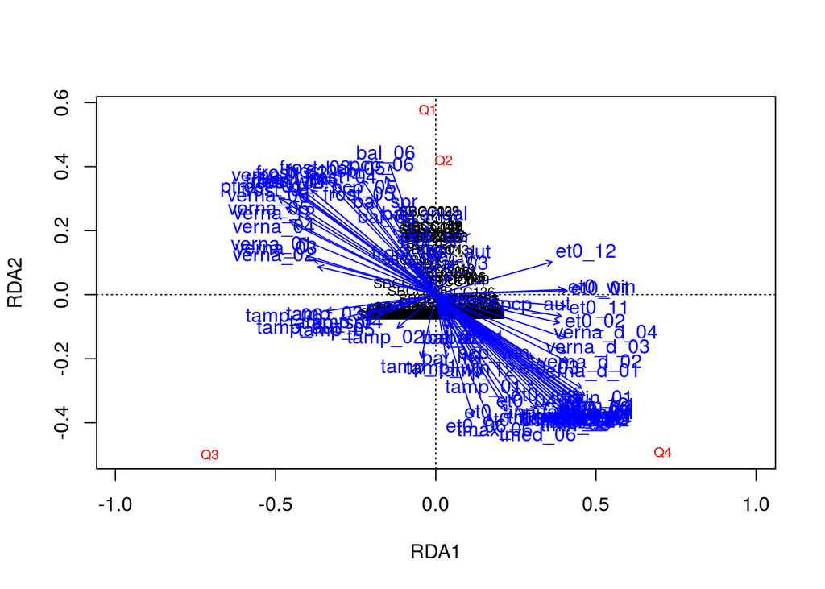

```r
#Triplot of rda results, check scaling options in help file
plot(SBCC_RDA,type="text", scaling=0)
```

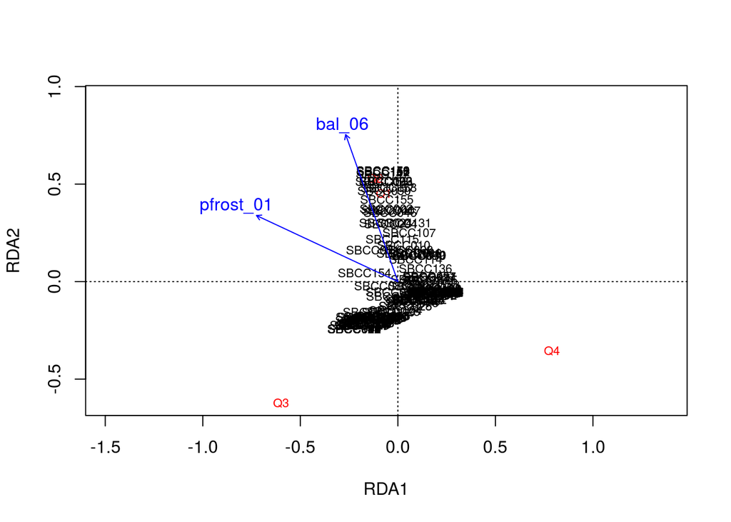

```r
plot(SBCC_RDA_red,type="text", scaling=0)
```

Third redundancy analysis with just 17 chosen environmental (agroclimatic) variables.

```r
#Redundancy analysis, complete data set
SBCCc_RDA<-rda(Clusterc,Envc,scale=F)
```

Information on outcome of RDA. Variance inflation ratio informs on multicollinearity (values above 10 are too high). R-squared adjusted for the number of parameters indicates proportion of variation explained

```r
#variance inflation ratio, above 10 indicates multicolinearity
vif.cca(SBCCc_RDA)
```

```
      verna_30d   verna_jan_feb   verna_mar_apr       pfrost_01
     742.997516       99.174744      489.132365       44.955736
        pcp_aut         pcp_win     pcp_mar_apr     pcp_may_jun
     229.443398      258.416685      251.925945      209.041842
  frost_jan_feb   frost_apr_may        tamp_win        tamp_spr
      24.344763       12.073368        6.939531       11.120701
        et0_spr         bal_aut         bal_win         bal_jun
     619.553508      310.071210      249.272417      139.253122
bal_mar_apr_may
    1425.818277
```

```r
#R-squared, raw and adjusted, explained by rda
RsquareAdj(SBCCc_RDA)
```

```
$r.squared
[1] 0.3735195

$adj.r.squared
[1] 0.2817077
```

Plot of redundancy analyses, scaling=0 chosen, as it results in good visualization of the plot; see help of the package for other scaling options

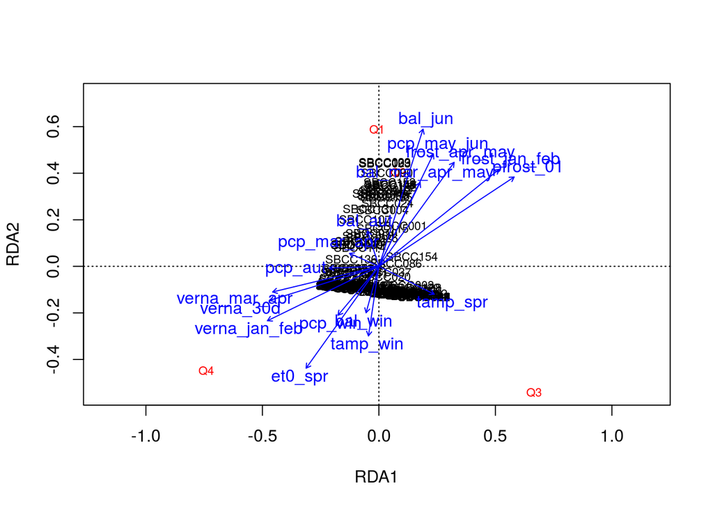

```r
#Triplot of rda results, check scaling options in help file
plot(SBCCc_RDA,type="text", scaling=0)
```

Variance of distribution of germplasm groups explained by #1 full model (all agro-climatic variables); #2 geographic variables, after agro-climatic variables are taken into account; #3 agro-climatic variables are taken into account. Significance calculated.

```r
#Variance explained by different fractions of variables
#1
anova(SBCCc_RDA)
```

```
Permutation test for rda under reduced model
Permutation: free
Number of permutations: 999

Model: rda(X = Clusterc, Y = Envc, scale = F)
          Df Variance      F Pr(>F)
Model     17  0.15287 4.0683  0.001 ***
Residual 116  0.25640
---
Signif. codes:  0 '***' 0.001 '**' 0.01 '*' 0.05 '.' 0.1 ' ' 1
```

```r
#2
anova.cca(rda(Clusterc,Geoc,Envc),step=1000)
```

```
Permutation test for rda under reduced model
Permutation: free
Number of permutations: 999

Model: rda(X = Clusterc, Y = Geoc, Z = Envc)
          Df Variance      F Pr(>F)
Model      3 0.003595 0.5356  0.841
Residual 113 0.252810
```

```r
#3
anova.cca(rda(Clusterc,Envc,Geoc),step=1000)
```

```
Permutation test for rda under reduced model
Permutation: free
Number of permutations: 999

Model: rda(X = Clusterc, Y = Envc, Z = Geoc)
          Df Variance      F Pr(>F)
Model     17  0.06711 1.7645  0.008 **
Residual 113  0.25281
---
Signif. codes:  0 '***' 0.001 '**' 0.01 '*' 0.05 '.' 0.1 ' ' 1
```

Percentage of variation of distribution of germplasm groups explained by environmental (agro-climatic) variables alone (fraction a), geographic variables alone (fraction c), environmental and geographic simultaneously (fraction b). Self-explanatory plot

```r
# Variation partitioning
spe.part <- varpart(Clusterc, Envc, Geoc)
spe.part
```

```
Partition of variance in RDA

Call: varpart(Y = Clusterc, X = Envc, Geoc)

Explanatory tables:
X1:  Envc
X2:  Geoc

No. of explanatory tables: 2
Total variation (SS): 54.434
            Variance: 0.40928
No. of observations: 134

Partition table:
                     Df R.squared Adj.R.squared Testable
[a+b] = X1           17   0.37352       0.28171     TRUE
[b+c] = X2            3   0.21833       0.20029     TRUE
[a+b+c] = X1+X2      20   0.38230       0.27298     TRUE
Individual fractions
[a] = X1|X2          17                 0.07268     TRUE
[b]                   0                 0.20902    FALSE
[c] = X2|X1           3                -0.00873     TRUE
[d] = Residuals                         0.72702    FALSE
---
Use function 'rda' to test significance of fractions of interest
```

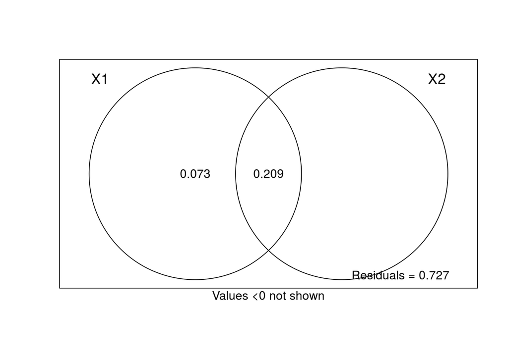

```r
plot(spe.part, digits=2)
```

Test of variance explained by different sets of variables

```r
# Test of fractions [a+b], only environmental variables
anova.cca(rda(Clusterc, Envc), step=1000)
```

```
Permutation test for rda under reduced model
Permutation: free
Number of permutations: 999

Model: rda(X = Clusterc, Y = Envc)
          Df Variance      F Pr(>F)
Model     17  0.15287 4.0683  0.001 ***
Residual 116  0.25640
---
Signif. codes:  0 '***' 0.001 '**' 0.01 '*' 0.05 '.' 0.1 ' ' 1
```

```r
# Test of fractions [b+c], only geographic variables
anova.cca(rda(Clusterc, Geoc), step=1000)
```

```
Permutation test for rda under reduced model
Permutation: free
Number of permutations: 999

Model: rda(X = Clusterc, Y = Geoc)
          Df Variance      F Pr(>F)
Model      3  0.08936 12.104  0.001 ***
Residual 130  0.31992
---
Signif. codes:  0 '***' 0.001 '**' 0.01 '*' 0.05 '.' 0.1 ' ' 1
```

```r
# Test of fractions [a+b+c], union of environmental and geographic
env.pars <- cbind(Envc, Geoc)
anova.cca(rda(Clusterc, env.pars), step=1000)
```

```
Permutation test for rda under reduced model
Permutation: free
Number of permutations: 999

Model: rda(X = Clusterc, Y = env.pars)
          Df Variance      F Pr(>F)
Model     20  0.15647 3.4969  0.001 ***
Residual 113  0.25281
---
Signif. codes:  0 '***' 0.001 '**' 0.01 '*' 0.05 '.' 0.1 ' ' 1
```

```r
#Test of fraction [a], environmental variables, excluding variation shared with geographic
anova.cca(rda(Clusterc, Envc, Geoc), step=1000)
```

```
Permutation test for rda under reduced model
Permutation: free
Number of permutations: 999

Model: rda(X = Clusterc, Y = Envc, Z = Geoc)
          Df Variance      F Pr(>F)
Model     17  0.06711 1.7645  0.005 **
Residual 113  0.25281
---
Signif. codes:  0 '***' 0.001 '**' 0.01 '*' 0.05 '.' 0.1 ' ' 1
```

```r
#Test of fraction [c], geographic variables, excluding variation shared with environmental (b)
anova.cca(rda(Clusterc, Geoc, Envc), step=1000)
```

```
Permutation test for rda under reduced model
Permutation: free
Number of permutations: 999

Model: rda(X = Clusterc, Y = Geoc, Z = Envc)
          Df Variance      F Pr(>F)
Model      3 0.003595 0.5356  0.831
Residual 113 0.252810
```

Export results, files stored in directory RDA:

```r
Scores<-scores(SBCCc_RDA)
Summaries<-summary(SBCCc_RDA)
write.table(Scores$sites,'RDA/scores_genotypes.txt', sep='\t')
write.table(Summaries$biplot,'RDA/scores_env.txt', sep='\t')
write.table(Scores$species,'RDA/scores_germplasmgroups.txt', sep='\t')
```